# Week 2: Review & SEM FUNdamentals

EDEP 625 Structural Equation Modeling

Susanne DeVore, PhD

2026-10-14

## Agenda

1. Methods walk through expectations & sign up
2. Logistics Updates
3. Data discussion
4. Variance, covariance, correlation, regression, multiple regression, and interactions
5. R lab
6. Systems of Equations
7. Homework: Example paper of Measured Variable Path Analysis

## Updates

1. Downloadable deck for w01 updated
2. AI Fair Use for class added to syllabus
- living doc - open to future discussion
3. Office hours: Changed to Mon 2:30-3:30 or by apt. Sign up link added

## Data Discussions

- What is the data set?
- Where did it come from?
- Examples of interesting variables
- What research questions you could address with it

## Methods walk through

Assignment: Lamaku > Assignments > methods walkthrough

Template: Course website: https://srdevore.github.io/edep_625_sem/

## Variance

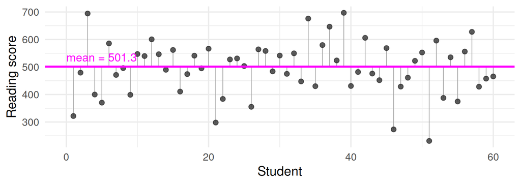

$$s^2 = \frac{\sum_{i=1}^{n}(y_i - \bar{y})^2}{n - 1}$$

$s^2$ = 11,295.8 $s$ = 106.3

## Covariance

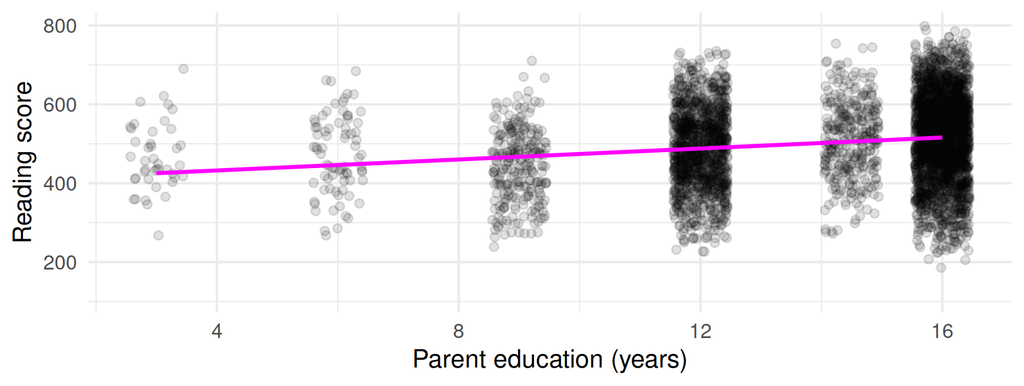

$$\mathrm{cov}(x, y) = \frac{\sum_{i=1}^{n}(x_i - \bar{x})(y_i - \bar{y})}{n - 1}$$

cov = 49.54

## Correlation

Covariance

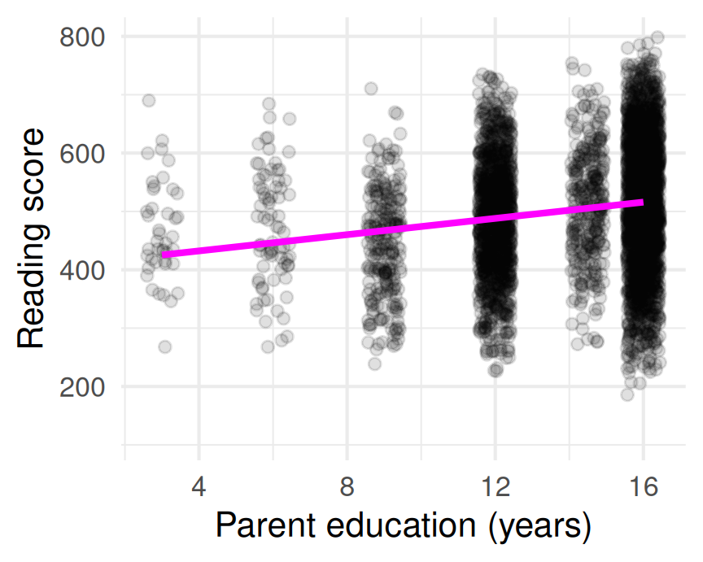

Covariance = **49.54**

Correlation

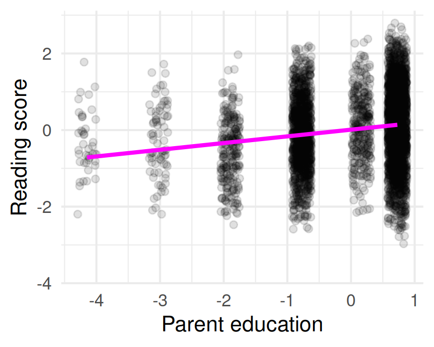

Correlation = **0.174**

$$r = \frac{\mathrm{cov}(x, y)}{s_x \, s_y}$$

## Correlation p2

|  | Reading | Parent ed | Books |
| --- | --- | --- | --- |
| Reading | 1.00 | 0.17 | 0.42 |
| Parent ed | 0.17 | 1.00 | 0.27 |
| Books | 0.42 | 0.27 | 1.00 |

## Regression

$$\hat{y} = b_0 + b_1 x_1$$

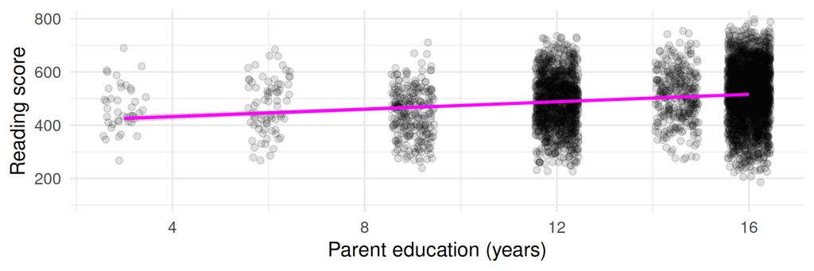

| Term | Estimate | SE | t | p |
| --- | --- | --- | --- | --- |
| Intercept | 502.41 | 1.6 | 314.24 | < .001 |
| Parent education | 6.97 | 0.6 | 11.62 | < .001 |

$R^2$ = 0.030, adj. $R^2$ = 0.030, $F$(1, 4,327) = 135.0, $p$ < .001, residual SE = 105.2

## Multiple Regression 1

$$\hat{y} = b_0 + b_1 x_1 + b_2 x_2$$

| Term | Estimate | SE | t | p |
| --- | --- | --- | --- | --- |
| Intercept | 495.48 | 1.57 | 315.31 | < .001 |
| Parent education | 2.00 | 0.60 | 3.35 | < .001 |
| Books at home | 29.64 | 1.11 | 26.70 | < .001 |

$R^2$ = 0.182, adj. $R^2$ = 0.181, $F$(2, 3,764) = 417.4, $p$ < .001, residual SE = 96.3

## Interaction in Multiple Regression 1

$$\hat{y} = b_0 + b_1 x_1 + b_2 x_2 + b_3 (x_1 \times x_2)$$

## Interaction in Multiple Regression 2

| Term | Estimate | SE | t | p |
| --- | --- | --- | --- | --- |
| Intercept | 494.60 | 1.64 | 301.15 | < .001 |
| Parent education | 2.49 | 0.65 | 3.81 | < .001 |
| Books at home | 29.14 | 1.14 | 25.50 | < .001 |
| Parent education x Books | 0.87 | 0.47 | 1.85 | 0.064 |

$R^2$ = 0.182, adj. $R^2$ = 0.182, $F$(3, 3,763) = 279.6, $p$ < .001, residual SE = 96.3

## Problem

- There is a correlation between books at home & parent education (r = 0.27)
- What is the real-world relationship between them?

## Mediation Effect

- parent education > more books in home > reading score

$$\widehat{\text{Books}} = a_0 + a_1(\text{ParentEd})$$
$$\widehat{\text{Reading}} = b_0 + b_1(\text{Books})$$

- Books at home is an *outcome* of parental education in the first equation and a *predictor* of reading score in the second.
- Cannot be captured by regression, multiple regression, or interaction effects.

## Rlab 2

- Write a short interpretation of each of the models.
- Compare the models: Which is the best? Why?
- Save somewhere you can easily find it again. We will come back to this in future weeks.

## Solving Systems of Equations 1

Two equations, four unknown variables & 2 disturbances

$$\text{Books} = a_0 + a_1(\text{ParentEd}) + \zeta_B$$
$$\text{Reading} = b_0 + b_1(\text{Books}) + \zeta_R$$

Paramters: $a_0$, $a_1$, $b_0$, $b_1$, $zeta_B$, $zeta_R$, Var(ParentEd).

This equation system implies covariances. We use the model-implied covariances to solve.

## First Equation — Step 1: The model

$$\text{Books} = a_0 + a_1(\text{ParentEd}) + \zeta_B$$

$\zeta_B$ is the disturbance (what ParentEd does not explain). In SEM we assume it is uncorrelated with the predictor:

$$\mathrm{cov}(\text{ParentEd},\, \zeta_B) = 0$$

## First Equation — Step 2: Covary both sides with ParentEd

Take the covariance of each side with ParentEd:

$$\mathrm{cov}(\text{ParentEd},\, \text{Books})
= \mathrm{cov}\big(\text{ParentEd},\; a_0 + a_1\text{ParentEd} + \zeta_B\big)$$

## First Equation — Step 3: Distribute the covariance

$$\mathrm{cov}(\text{ParentEd}, \text{Books}) =
\mathrm{cov}(\text{ParentEd}, a_0)
+ a_1\,\mathrm{cov}(\text{ParentEd}, \text{ParentEd})
+ \mathrm{cov}(\text{ParentEd}, \zeta_B)$$

## First Equation — Step 4: Simplify each term

- $\mathrm{cov}(\text{ParentEd}, a_0) = 0$ (covariance with a constant)
- $\mathrm{cov}(\text{ParentEd}, \text{ParentEd}) = s^2_{\text{ParentEd}}$
- $\mathrm{cov}(\text{ParentEd}, \zeta_B) = 0$ (our assumption)

$$\mathrm{cov}(\text{ParentEd}, \text{Books}) = a_1\, s^2_{\text{ParentEd}}$$

## First Equation — Step 5: Solve for $a_1$

Divide both sides by $s^2_{\text{ParentEd}}$:

$$a_1 = \frac{\mathrm{cov}(\text{ParentEd}, \text{Books})}{s^2_{\text{ParentEd}}}$$

## First Equation — Step 6: Plug in the numbers

$$a_1 = \frac{1.092}{7.11} = 0.154$$

## First Equation — Step 7: Back out the intercept $a_0$

The line passes through the means, so:

$$a_0 = \overline{\text{Books}} - a_1 \times \overline{\text{ParentEd}}
= 3.30 - 0.154 \times 14.06
= 1.14$$

## Second Equation

Repeat the steps for the second equation.

## The Solved System

$$\widehat{\text{Books}} = 1.14 + 0.154(\text{ParentEd})$$
$$\widehat{\text{Reading}} = 399.7 + 30.81(\text{Books})$$

- Solved using model-implied covariances algebraically
- Merely ~14 steps
- simplest possible MVPA model

## Solving Systems of Equations: Maximum Likelihood

Objective:

- Find the parameter values that **maximize** the **likelihood** of the observed data.
- Given a candidate set of parameters, how **likely** is it that I’d see exactly this pattern of real values?

## Maximum Likelihood Estimation (MLE)

- Initialize the parameters ($\theta$) with reasonable starting guesses.

## Maximum Likelihood: Continued

After we make our first guess at the parameters

- compute the model-implied covariance matrix $\Sigma(\theta)$
- compare it to the observed covariance matrix $S$
- use the ML fit function to see how far off the model is from the data.
  - we want this to be as small as possible

## ML fit function

$$F_{ML} = \log|\Sigma(\theta)| + \text{tr}(S\,\Sigma(\theta)^{-1}) - \log|S| - p$$

Where:

- $S$ = observed covariance matrix (from our data)
- $\Sigma(\theta)$ = model-implied covariance matrix
- $\theta$ = parameters
- $p$ = number of observed variables

## Maximum likelihood

$$F_{ML} = \log|\Sigma(\theta)| + \text{tr}(S\,\Sigma(\theta)^{-1}) - \log|S| - p$$

Where:

- log|Σ(θ)|: a single number representing total model-implied variance
- tr(SΣ(θ)⁻¹): how well the model structure fits the actual data
- log|S|: how much variance is in the observed data

## Pause & Recap

Maximum likelihood estimation represents the **objective** of what we want to do.

Conceptually, what is our objective?

## Gradient Descent:

Maximizing the likelihood of the observed data = minimizing the distance between model-implied and observed covariance matrices

## Gradient Descent: Finding the Valley

The search: Iterative optemizer

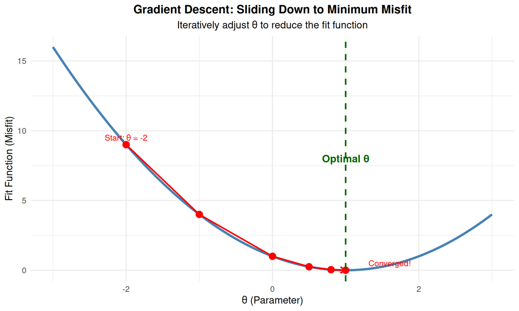

## Pause & Recap

Gradient Descent represents a search for the best paramters.

Conceptually, how does it work?

## Updating Parameters: The Learning Process

**Update Rule:**

$$\theta_j^{\text{(new)}} = \theta_j^{\text{(old)}} - \text{step size} \times \text{gradient}$$

- Gradient tells us the direction & steepness of the curve
- Step size controls how far we move (a small increment, not a full unit)
- Too large → might overshoot the valley
- Too small → takes forever to converge

## Pause & Recap

Objective: Maximum likelihood

Search: Gradient descent

How to update parameters: Update rule

Conceptually, how do these three work together?

## Up Next

Measured Variable Path Analysis Specification

Review anything new from today!!

Prep: read the article